# Name: Han Hong Tuck from EP0302_01

## Title of Data Analysis: How do Global Events influence Singapore's Economic Growth?

### Questions to answer to gain deeper insights into dataset:

#### Question 1: What is the relationship between GDP Growth rate and Contributors to GDP Growth Rate by Industry

#### Question 2: Why are there fluctations in the GDP Growth rate by industry and how does that influence the overall GDP Growth Rate Annually?

#### Question 3: What is the trend for the GDP Growth Rate as well as GDP Growth Rate by Industry of the individual datasets?

Url of Annual Contribution to Growth in Gross Domestic Product in Chained 2015 dollars Dataset: https://data.gov.sg/dataset/contribution-to-growth-in-gdp-in-chained-2015-dollars-by-industry-ssic-2015-annual

Url of Annual Contribution to Growth in Gross Domestic Product in Chained 2015 dollars (By Industry) Dataset: https://data.gov.sg/dataset/contribution-to-growth-in-gdp-in-chained-2015-dollars-by-industry-ssic-2015-annual?resource_id=2391f506-3f78-4041-a97d-5ed1c8c48083

### Breaking Down the Nature of GDP Growth Dataset:

The nature of the GDP Growth dataset contains the GDP Growth Rate for Singapore from 1960s to 2010s.

#### What is Gross Domestic Product (GDP) ?

Gross Domestic Product (GDP) is an important economic indicator of the country's performance over a given period, by measuring the total monetary or market value produced by the country.

#### Why is Growth in Gross Domestic Product (GDP) important?

Since the growth rate of Gross Domestic Product (GDP) is often used as an indicator of the general health of the economy, an increase in GDP is often interpreted as a sign that the economy is doing well.

#### What is the metric used to measure the Growth in Gross Domestic Product (GDP)?

The metric used in measuring the Growth in Gross Domestic Product (GDP) for this dataset is using Chained Dollars. Chained dollars is used to adjust the real dollar amounts for inflation over time. When using chained dollars, a base year will be chosen to calculate the actual inflation in the economy, so as to make it fair for comparing the Gross Domestic Product (GDP) Growth across different years. In order to capture the economic information accurately, the base year chosen has to be constantly updated to recent years. The base year also needs to be taken into consideration of the economic environment of the period (relatively stable economic performance), considered somewhere in the middle between high economic performance and low economic performance indicators. Hence, the base year for this dataset is 2015.

#### Write Python code that uses the pandas package to extract useful statistical or summary information about the data

```python
import pandas as pd
import numpy as np

gdp_growth = pd.read_csv("./Datasets/contribution-to-growth-in-gross-domestic-product-in-chained-2015-dollars-annual.csv")

#Shape of GDP Growth Dataset
print(f"Shape of the GDP Growth Dataset: {gdp_growth.shape}\n")

#Index of GDP Growth Dataset
print(f"Index of the GDP Growth Dataset: {gdp_growth.index}\n")

#Column of GDP Growth Dataset
print(f"Columns of the GDP Growth Dataset: \n{gdp_growth.columns}")

#Renaming the column names
gdp_growth.rename(columns=
    {"year":"Financial Year",
     "level_1":"GDP Growth in Chained Dollars (Base Year = 2015)",
     "value":"Percentage Growth (%)"}
    ,inplace=True)

#First 5 rows of GDP Growth Dataset
print("\n\t\tFirst 5 rows of GDP Growth Dataset")
display(gdp_growth.head())

#Last 5 rows of GDP Growth Dataset
print("\n\t\tLast 5 rows of GDP Growth Dataset")
display(gdp_growth.tail())

#Display Summary Information of GDP Growth Dataset
print("\n\t\tSummary infomation of GDP Growth Dataset\n")
display(gdp_growth.info())

#Display top 10 years with fastest GDP Growth
print("\n\t\tTop 10 Years with Fastest GDP Growth in chronological order")
highest_gdp = gdp_growth.sort_values(by="Percentage Growth (%)",ascending=False).head(10)

#convert column for GDP Growth to index using pivot
highest_gdp = highest_gdp.pivot(index="GDP Growth in Chained Dollars (Base Year = 2015)",columns = "Financial Year")
display(highest_gdp)

#Display top 10 years with slowest GDP Growth
print("\n\t\tTop 10 Years with Slowest GDP Growth in chronological order")
slowest_gdp = gdp_growth.sort_values(by="Percentage Growth (%)",ascending=False).tail(10)

#convert column for GDP Growth to index using pivot
slowest_gdp = slowest_gdp.pivot(index="GDP Growth in Chained Dollars (Base Year = 2015)",columns = "Financial Year")
display(slowest_gdp)
```

```
Shape of the GDP Growth Dataset: (58, 3)

Index of the GDP Growth Dataset: RangeIndex(start=0, stop=58, step=1)

Columns of the GDP Growth Dataset:
Index(['year', 'level_1', 'value'], dtype='object')

		First 5 rows of GDP Growth Dataset
```

|  | Financial Year | GDP Growth in Chained Dollars (Base Year = 2015) | Percentage Growth (%) |
| --- | --- | --- | --- |
| 0 | 1961 | GDP In Chained (2015) Dollars | 8.1 |
| 1 | 1962 | GDP In Chained (2015) Dollars | 7.6 |
| 2 | 1963 | GDP In Chained (2015) Dollars | 10.0 |
| 3 | 1964 | GDP In Chained (2015) Dollars | -3.1 |
| 4 | 1965 | GDP In Chained (2015) Dollars | 7.8 |

```
		Last 5 rows of GDP Growth Dataset
```

|  | Financial Year | GDP Growth in Chained Dollars (Base Year = 2015) | Percentage Growth (%) |
| --- | --- | --- | --- |
| 53 | 2014 | GDP In Chained (2015) Dollars | 3.9 |
| 54 | 2015 | GDP In Chained (2015) Dollars | 2.9 |
| 55 | 2016 | GDP In Chained (2015) Dollars | 3.0 |
| 56 | 2017 | GDP In Chained (2015) Dollars | 3.7 |
| 57 | 2018 | GDP In Chained (2015) Dollars | 3.1 |

```
		Summary infomation of GDP Growth Dataset

<class 'pandas.core.frame.DataFrame'>
RangeIndex: 58 entries, 0 to 57
Data columns (total 3 columns):
 #   Column                                            Non-Null Count  Dtype
---  ------                                            --------------  -----
 0   Financial Year                                    58 non-null     int64
 1   GDP Growth in Chained Dollars (Base Year = 2015)  58 non-null     object
 2   Percentage Growth (%)                             58 non-null     float64
dtypes: float64(1), int64(1), object(1)
memory usage: 1.5+ KB
```

```
None
```

```
		Top 10 Years with Fastest GDP Growth in chronological order
```

| Financial Year GDP Growth in Chained Dollars (Base Year = 2015) | Percentage Growth (%) 1967 | Percentage Growth (%) 1968 | Percentage Growth (%) 1969 | Percentage Growth (%) 1970 | Percentage Growth (%) 1971 | Percentage Growth (%) 1972 | Percentage Growth (%) 1988 | Percentage Growth (%) 1993 | Percentage Growth (%) 1994 | Percentage Growth (%) 2010 |
| --- | --- | --- | --- | --- | --- | --- | --- | --- | --- | --- |
| GDP In Chained (2015) Dollars | 12.5 | 13.5 | 13.8 | 13.9 | 12.4 | 13.3 | 11.3 | 11.5 | 11.1 | 14.5 |

```
		Top 10 Years with Slowest GDP Growth in chronological order
```

| Financial Year GDP Growth in Chained Dollars (Base Year = 2015) | Percentage Growth (%) 1964 | Percentage Growth (%) 1985 | Percentage Growth (%) 1986 | Percentage Growth (%) 1998 | Percentage Growth (%) 2001 | Percentage Growth (%) 2008 | Percentage Growth (%) 2009 | Percentage Growth (%) 2015 | Percentage Growth (%) 2016 | Percentage Growth (%) 2018 |
| --- | --- | --- | --- | --- | --- | --- | --- | --- | --- | --- |
| GDP In Chained (2015) Dollars | -3.1 | -0.6 | 1.3 | -2.2 | -1.1 | 1.9 | 0.1 | 2.9 | 3.0 | 3.1 |

```python
data1 = [1961,1970,1980,1990,2000,2010]
data2 = [1969,1979,1989,1999,2009,2018]
years = 1960

#using loop to display the gdp growth every 10 years
for index, (value1, value2) in enumerate(zip(data1, data2)):
    print(f"\n\t\t\t   GDP Growth in {years}s")
    gdp_growth_every_ten_years = gdp_growth.set_index("Financial Year").loc[value1:value2,:].reset_index()

    #extract statistical info about the gdp every 10 years
    gdp_statistical_info = gdp_growth_every_ten_years.groupby(["GDP Growth in Chained Dollars (Base Year = 2015)"])[["Percentage Growth (%)"]].describe()

    #using pivot to convert the column gdp to index
    gdp_growth_every_ten_years = gdp_growth_every_ten_years.pivot(index="GDP Growth in Chained Dollars (Base Year = 2015)", columns = "Financial Year")

    display(gdp_growth_every_ten_years)

    print(f"\n\t\tStatistical Information for GDP Growth in {years}s")
    display(gdp_statistical_info)
    years += 10
```

```
			   GDP Growth in 1960s
```

| Financial Year GDP Growth in Chained Dollars (Base Year = 2015) | Percentage Growth (%) 1961 | Percentage Growth (%) 1962 | Percentage Growth (%) 1963 | Percentage Growth (%) 1964 | Percentage Growth (%) 1965 | Percentage Growth (%) 1966 | Percentage Growth (%) 1967 | Percentage Growth (%) 1968 | Percentage Growth (%) 1969 |
| --- | --- | --- | --- | --- | --- | --- | --- | --- | --- |
| GDP In Chained (2015) Dollars | 8.1 | 7.6 | 10.0 | -3.1 | 7.8 | 10.2 | 12.5 | 13.5 | 13.8 |

```
		Statistical Information for GDP Growth in 1960s
```

| GDP Growth in Chained Dollars (Base Year = 2015) | Percentage Growth (%) count | Percentage Growth (%) mean | Percentage Growth (%) std | Percentage Growth (%) min | Percentage Growth (%) 25% | Percentage Growth (%) 50% | Percentage Growth (%) 75% | Percentage Growth (%) max |
| --- | --- | --- | --- | --- | --- | --- | --- | --- |
| GDP In Chained (2015) Dollars | 9.0 | 8.933333 | 5.105879 | -3.1 | 7.8 | 10.0 | 12.5 | 13.8 |

```
			   GDP Growth in 1970s
```

| Financial Year GDP Growth in Chained Dollars (Base Year = 2015) | Percentage Growth (%) 1970 | Percentage Growth (%) 1971 | Percentage Growth (%) 1972 | Percentage Growth (%) 1973 | Percentage Growth (%) 1974 | Percentage Growth (%) 1975 | Percentage Growth (%) 1976 | Percentage Growth (%) 1977 | Percentage Growth (%) 1978 | Percentage Growth (%) 1979 |
| --- | --- | --- | --- | --- | --- | --- | --- | --- | --- | --- |
| GDP In Chained (2015) Dollars | 13.9 | 12.4 | 13.3 | 10.6 | 6.1 | 4.0 | 7.4 | 6.9 | 7.8 | 9.6 |

```
		Statistical Information for GDP Growth in 1970s
```

| GDP Growth in Chained Dollars (Base Year = 2015) | Percentage Growth (%) count | Percentage Growth (%) mean | Percentage Growth (%) std | Percentage Growth (%) min | Percentage Growth (%) 25% | Percentage Growth (%) 50% | Percentage Growth (%) 75% | Percentage Growth (%) max |
| --- | --- | --- | --- | --- | --- | --- | --- | --- |
| GDP In Chained (2015) Dollars | 10.0 | 9.2 | 3.306559 | 4.0 | 7.025 | 8.7 | 11.95 | 13.9 |

```
			   GDP Growth in 1980s
```

| Financial Year GDP Growth in Chained Dollars (Base Year = 2015) | Percentage Growth (%) 1980 | Percentage Growth (%) 1981 | Percentage Growth (%) 1982 | Percentage Growth (%) 1983 | Percentage Growth (%) 1984 | Percentage Growth (%) 1985 | Percentage Growth (%) 1986 | Percentage Growth (%) 1987 | Percentage Growth (%) 1988 | Percentage Growth (%) 1989 |
| --- | --- | --- | --- | --- | --- | --- | --- | --- | --- | --- |
| GDP In Chained (2015) Dollars | 10.1 | 10.8 | 7.1 | 8.6 | 8.8 | -0.6 | 1.3 | 10.8 | 11.3 | 10.2 |

```
		Statistical Information for GDP Growth in 1980s
```

| GDP Growth in Chained Dollars (Base Year = 2015) | Percentage Growth (%) count | Percentage Growth (%) mean | Percentage Growth (%) std | Percentage Growth (%) min | Percentage Growth (%) 25% | Percentage Growth (%) 50% | Percentage Growth (%) 75% | Percentage Growth (%) max |
| --- | --- | --- | --- | --- | --- | --- | --- | --- |
| GDP In Chained (2015) Dollars | 10.0 | 7.84 | 4.16632 | -0.6 | 7.475 | 9.45 | 10.65 | 11.3 |

```
			   GDP Growth in 1990s
```

| Financial Year GDP Growth in Chained Dollars (Base Year = 2015) | Percentage Growth (%) 1990 | Percentage Growth (%) 1991 | Percentage Growth (%) 1992 | Percentage Growth (%) 1993 | Percentage Growth (%) 1994 | Percentage Growth (%) 1995 | Percentage Growth (%) 1996 | Percentage Growth (%) 1997 | Percentage Growth (%) 1998 | Percentage Growth (%) 1999 |
| --- | --- | --- | --- | --- | --- | --- | --- | --- | --- | --- |
| GDP In Chained (2015) Dollars | 9.8 | 6.7 | 6.6 | 11.5 | 11.1 | 7.2 | 7.5 | 8.3 | -2.2 | 5.7 |

```
		Statistical Information for GDP Growth in 1990s
```

| GDP Growth in Chained Dollars (Base Year = 2015) | Percentage Growth (%) count | Percentage Growth (%) mean | Percentage Growth (%) std | Percentage Growth (%) min | Percentage Growth (%) 25% | Percentage Growth (%) 50% | Percentage Growth (%) 75% | Percentage Growth (%) max |
| --- | --- | --- | --- | --- | --- | --- | --- | --- |
| GDP In Chained (2015) Dollars | 10.0 | 7.22 | 3.843841 | -2.2 | 6.625 | 7.35 | 9.425 | 11.5 |

```
			   GDP Growth in 2000s
```

| Financial Year GDP Growth in Chained Dollars (Base Year = 2015) | Percentage Growth (%) 2000 | Percentage Growth (%) 2001 | Percentage Growth (%) 2002 | Percentage Growth (%) 2003 | Percentage Growth (%) 2004 | Percentage Growth (%) 2005 | Percentage Growth (%) 2006 | Percentage Growth (%) 2007 | Percentage Growth (%) 2008 | Percentage Growth (%) 2009 |
| --- | --- | --- | --- | --- | --- | --- | --- | --- | --- | --- |
| GDP In Chained (2015) Dollars | 9.0 | -1.1 | 3.9 | 4.5 | 9.8 | 7.4 | 9.0 | 9.0 | 1.9 | 0.1 |

```
		Statistical Information for GDP Growth in 2000s
```

| GDP Growth in Chained Dollars (Base Year = 2015) | Percentage Growth (%) count | Percentage Growth (%) mean | Percentage Growth (%) std | Percentage Growth (%) min | Percentage Growth (%) 25% | Percentage Growth (%) 50% | Percentage Growth (%) 75% | Percentage Growth (%) max |
| --- | --- | --- | --- | --- | --- | --- | --- | --- |
| GDP In Chained (2015) Dollars | 10.0 | 5.35 | 4.053325 | -1.1 | 2.4 | 5.95 | 9.0 | 9.8 |

```
			   GDP Growth in 2010s
```

| Financial Year GDP Growth in Chained Dollars (Base Year = 2015) | Percentage Growth (%) 2010 | Percentage Growth (%) 2011 | Percentage Growth (%) 2012 | Percentage Growth (%) 2013 | Percentage Growth (%) 2014 | Percentage Growth (%) 2015 | Percentage Growth (%) 2016 | Percentage Growth (%) 2017 | Percentage Growth (%) 2018 |
| --- | --- | --- | --- | --- | --- | --- | --- | --- | --- |
| GDP In Chained (2015) Dollars | 14.5 | 6.3 | 4.4 | 4.8 | 3.9 | 2.9 | 3.0 | 3.7 | 3.1 |

```
		Statistical Information for GDP Growth in 2010s
```

| GDP Growth in Chained Dollars (Base Year = 2015) | Percentage Growth (%) count | Percentage Growth (%) mean | Percentage Growth (%) std | Percentage Growth (%) min | Percentage Growth (%) 25% | Percentage Growth (%) 50% | Percentage Growth (%) 75% | Percentage Growth (%) max |
| --- | --- | --- | --- | --- | --- | --- | --- | --- |
| GDP In Chained (2015) Dollars | 9.0 | 5.177778 | 3.656767 | 2.9 | 3.1 | 3.9 | 4.8 | 14.5 |

### Breaking Down the Nature of GDP Growth by Industry Dataset:

The nature of the GDP Growth by industry contains the contribution of the GDP Growth for Singapore from 1960s to 2010s sorted by their respective industries (Goods Producing Industries, Services Producing Industries, Ownership Of Dwellings, Add: Taxes On Products). These sectors help to contribute the GDP Growth of Singapore's economic development.

- Goods Producing Industries refers to industries from Mandfacturing, Construction, Utilities and other goods industries.
- Services Producing Industries refer to industries from Wholesale and Retail trade, Transportation and Storage, Accomodation and Food services and many more... It typically refers to industries that provide a service instead of end-products like financial consultants or insurance agents.
- Ownership of dwellings refers to revenue generated from Housing services provided by owner-occupiers and individuals who sell their residential properties.
- Taxes on products refers to taxes payable per unit of goods and services when they are produced, delivered, sold, transferred or disposed of by their producers. Examples include goods and services tax (GST), stamp duties and Certificate of Entitlement of motor vehicles.

```python
gdp_growth_by_industry = pd.read_csv("./Datasets/contribution-to-growth-in-gdp-in-chained-2015-dollars-by-industry-annual.csv")

#Shape of GDP Growth by Industry Dataset
print(f"Shape of the GDP Growth by Industry Dataset: {gdp_growth_by_industry.shape}\n")

#Index of GDP Growth by Industry Dataset
print(f"Index of the GDP Growth by Industry Dataset: {gdp_growth_by_industry.index}\n")

#Column of GDP Growth by Industry Dataset
print(f"Columns of the GDP Growth by Industry Dataset: \n{gdp_growth_by_industry.columns}")

#Renaming the column names
gdp_growth_by_industry.rename(columns=
    {"year":"Financial Year",
     "level_1":"GDP Growth in Chained Dollars (Base Year = 2015)",
     "level_2":"Type_of_Industries",
     "value":"Percentage Growth (%)"}
    ,inplace=True)

#First 5 rows of GDP Growth by Industry Dataset
print("\n\t\tFirst 5 rows of GDP Growth by Industry Dataset")
display(gdp_growth_by_industry.head())

#Last 5 rows of GDP Growth by Industry Dataset
print("\n\t\tLast 5 rows of GDP Growth by Industry Dataset")
display(gdp_growth_by_industry.tail())

#Display Information of GDP Growth by Industry Dataset
print("\n\t\tSummary infomation of GDP Growth by Industry Dataset\n")
display(gdp_growth_by_industry.info())

#Display Statistical Information of GDP Growth by Industry Dataset
print("\nStatistical infomation of Overall GDP Growth by Industry Dataset\n")
display(gdp_growth_by_industry.groupby(["Type_of_Industries"])[["Percentage Growth (%)"]].describe())

data1 = [1961,1970,1980,1990,2000,2010]
data2 = [1969,1979,1989,1999,2009,2018]
years = 1960

gdp_growth_by_industry.drop(["GDP Growth in Chained Dollars (Base Year = 2015)"],axis=1,inplace=True)

#using a loop to display the statistical information of gdp growth of all the data in 1960s... to 2010s
for index, (value1, value2) in enumerate(zip(data1, data2)):

    print(f"\n\t\t\tGDP Growth in {years}s")
    gdp_growth_every_ten_years = gdp_growth_by_industry.set_index("Financial Year").loc[value1:value2,:].reset_index()

    #extract statistical info about the gdp every 10 years
    gdp_statistical_info = gdp_growth_every_ten_years.groupby(["Type_of_Industries"])[["Percentage Growth (%)"]].describe()

    #using pivot to convert the column gdp to index
    gdp_growth_every_ten_years = gdp_growth_every_ten_years.pivot(index="Type_of_Industries", columns = "Financial Year")

    display(gdp_growth_every_ten_years)

    print(f"\nStatistical information of GDP Growth by Industry in {years}s")
    display(gdp_statistical_info)
    years += 10
```

```
Shape of the GDP Growth by Industry Dataset: (232, 4)

Index of the GDP Growth by Industry Dataset: RangeIndex(start=0, stop=232, step=1)

Columns of the GDP Growth by Industry Dataset:
Index(['year', 'level_1', 'level_2', 'value'], dtype='object')

		First 5 rows of GDP Growth by Industry Dataset
```

|  | Financial Year | GDP Growth in Chained Dollars (Base Year = 2015) | Type_of_Industries | Percentage Growth (%) |
| --- | --- | --- | --- | --- |
| 0 | 1961 | GDP In Chained (2015) Dollars | Goods Producing Industries | 1.8 |
| 1 | 1961 | GDP In Chained (2015) Dollars | Services Producing Industries | 5.9 |
| 2 | 1961 | GDP In Chained (2015) Dollars | Ownership Of Dwellings | 0.3 |
| 3 | 1961 | GDP In Chained (2015) Dollars | Add: Taxes On Products | 0.1 |
| 4 | 1962 | GDP In Chained (2015) Dollars | Goods Producing Industries | 1.9 |

```
		Last 5 rows of GDP Growth by Industry Dataset
```

|  | Financial Year | GDP Growth in Chained Dollars (Base Year = 2015) | Type_of_Industries | Percentage Growth (%) |
| --- | --- | --- | --- | --- |
| 227 | 2017 | GDP In Chained (2015) Dollars | Add: Taxes On Products | 0.3 |
| 228 | 2018 | GDP In Chained (2015) Dollars | Goods Producing Industries | 1.2 |
| 229 | 2018 | GDP In Chained (2015) Dollars | Services Producing Industries | 1.9 |
| 230 | 2018 | GDP In Chained (2015) Dollars | Ownership Of Dwellings | 0.2 |
| 231 | 2018 | GDP In Chained (2015) Dollars | Add: Taxes On Products | -0.1 |

```
		Summary infomation of GDP Growth by Industry Dataset

<class 'pandas.core.frame.DataFrame'>
RangeIndex: 232 entries, 0 to 231
Data columns (total 4 columns):
 #   Column                                            Non-Null Count  Dtype
---  ------                                            --------------  -----
 0   Financial Year                                    232 non-null    int64
 1   GDP Growth in Chained Dollars (Base Year = 2015)  232 non-null    object
 2   Type_of_Industries                                232 non-null    object
 3   Percentage Growth (%)                             232 non-null    float64
dtypes: float64(1), int64(1), object(2)
memory usage: 7.4+ KB
```

```
None
```

```
Statistical infomation of Overall GDP Growth by Industry Dataset
```

| Type_of_Industries | Percentage Growth (%) count | Percentage Growth (%) mean | Percentage Growth (%) std | Percentage Growth (%) min | Percentage Growth (%) 25% | Percentage Growth (%) 50% | Percentage Growth (%) 75% | Percentage Growth (%) max |
| --- | --- | --- | --- | --- | --- | --- | --- | --- |
| Add: Taxes On Products | 58.0 | 0.274138 | 0.354203 | -0.9 | 0.025 | 0.3 | 0.475 | 1.1 |
| Goods Producing Industries | 58.0 | 2.232759 | 1.852489 | -3.6 | 1.225 | 2.2 | 3.400 | 6.5 |
| Ownership Of Dwellings | 58.0 | 0.208621 | 0.173998 | -0.1 | 0.100 | 0.2 | 0.300 | 0.8 |
| Services Producing Industries | 58.0 | 4.582759 | 2.520870 | -4.8 | 3.050 | 4.9 | 6.300 | 8.9 |

```
			GDP Growth in 1960s
```

| Financial Year Type_of_Industries | Percentage Growth (%) 1961 | Percentage Growth (%) 1962 | Percentage Growth (%) 1963 | Percentage Growth (%) 1964 | Percentage Growth (%) 1965 | Percentage Growth (%) 1966 | Percentage Growth (%) 1967 | Percentage Growth (%) 1968 | Percentage Growth (%) 1969 |
| --- | --- | --- | --- | --- | --- | --- | --- | --- | --- |
| Add: Taxes On Products | 0.1 | 0.3 | 0.0 | 0.2 | 1.1 | 0.7 | 0.0 | 0.0 | 0.8 |
| Goods Producing Industries | 1.8 | 1.9 | 2.7 | 1.4 | 2.3 | 2.9 | 3.4 | 4.6 | 4.6 |
| Ownership Of Dwellings | 0.3 | 0.3 | 0.2 | 0.1 | 0.2 | 0.3 | 0.2 | 0.4 | 0.3 |
| Services Producing Industries | 5.9 | 5.1 | 7.1 | -4.8 | 4.2 | 6.3 | 8.9 | 8.5 | 8.1 |

```
Statistical information of GDP Growth by Industry in 1960s
```

| Type_of_Industries | Percentage Growth (%) count | Percentage Growth (%) mean | Percentage Growth (%) std | Percentage Growth (%) min | Percentage Growth (%) 25% | Percentage Growth (%) 50% | Percentage Growth (%) 75% | Percentage Growth (%) max |
| --- | --- | --- | --- | --- | --- | --- | --- | --- |
| Add: Taxes On Products | 9.0 | 0.355556 | 0.409607 | 0.0 | 0.0 | 0.2 | 0.7 | 1.1 |
| Goods Producing Industries | 9.0 | 2.844444 | 1.165237 | 1.4 | 1.9 | 2.7 | 3.4 | 4.6 |
| Ownership Of Dwellings | 9.0 | 0.255556 | 0.088192 | 0.1 | 0.2 | 0.3 | 0.3 | 0.4 |
| Services Producing Industries | 9.0 | 5.477778 | 4.162565 | -4.8 | 5.1 | 6.3 | 8.1 | 8.9 |

```
			GDP Growth in 1970s
```

| Financial Year Type_of_Industries | Percentage Growth (%) 1970 | Percentage Growth (%) 1971 | Percentage Growth (%) 1972 | Percentage Growth (%) 1973 | Percentage Growth (%) 1974 | Percentage Growth (%) 1975 | Percentage Growth (%) 1976 | Percentage Growth (%) 1977 | Percentage Growth (%) 1978 | Percentage Growth (%) 1979 |
| --- | --- | --- | --- | --- | --- | --- | --- | --- | --- | --- |
| Add: Taxes On Products | 0.9 | 0.2 | 0.7 | 0.4 | -0.3 | 0.0 | 0.1 | 0.3 | 0.2 | 0.5 |
| Goods Producing Industries | 5.3 | 4.7 | 5.2 | 2.6 | 1.2 | 1.0 | 3.7 | 2.1 | 2.2 | 3.8 |
| Ownership Of Dwellings | 0.4 | 0.2 | 0.4 | 0.1 | 0.2 | 0.1 | 0.1 | 0.2 | 0.1 | 0.2 |
| Services Producing Industries | 7.3 | 7.4 | 7.1 | 7.4 | 5.0 | 2.7 | 3.7 | 4.3 | 5.3 | 5.1 |

```
Statistical information of GDP Growth by Industry in 1970s
```

| Type_of_Industries | Percentage Growth (%) count | Percentage Growth (%) mean | Percentage Growth (%) std | Percentage Growth (%) min | Percentage Growth (%) 25% | Percentage Growth (%) 50% | Percentage Growth (%) 75% | Percentage Growth (%) max |
| --- | --- | --- | --- | --- | --- | --- | --- | --- |
| Add: Taxes On Products | 10.0 | 0.30 | 0.346410 | -0.3 | 0.125 | 0.25 | 0.475 | 0.9 |
| Goods Producing Industries | 10.0 | 3.18 | 1.587311 | 1.0 | 2.125 | 3.15 | 4.475 | 5.3 |
| Ownership Of Dwellings | 10.0 | 0.20 | 0.115470 | 0.1 | 0.100 | 0.20 | 0.200 | 0.4 |
| Services Producing Industries | 10.0 | 5.53 | 1.699052 | 2.7 | 4.475 | 5.20 | 7.250 | 7.4 |

```
			GDP Growth in 1980s
```

| Financial Year Type_of_Industries | Percentage Growth (%) 1980 | Percentage Growth (%) 1981 | Percentage Growth (%) 1982 | Percentage Growth (%) 1983 | Percentage Growth (%) 1984 | Percentage Growth (%) 1985 | Percentage Growth (%) 1986 | Percentage Growth (%) 1987 | Percentage Growth (%) 1988 | Percentage Growth (%) 1989 |
| --- | --- | --- | --- | --- | --- | --- | --- | --- | --- | --- |
| Add: Taxes On Products | 0.4 | 0.2 | 0.3 | 0.3 | 0.2 | 0.0 | 0.0 | 0.5 | 0.4 | 0.8 |
| Goods Producing Industries | 3.3 | 3.7 | 1.8 | 3.6 | 3.4 | -3.6 | -0.6 | 3.2 | 4.2 | 2.7 |
| Ownership Of Dwellings | 0.1 | 0.6 | -0.1 | 0.8 | 0.8 | 0.4 | 0.4 | 0.3 | 0.2 | 0.3 |
| Services Producing Industries | 6.3 | 6.2 | 5.2 | 3.9 | 4.4 | 2.5 | 1.5 | 6.7 | 6.4 | 6.4 |

```
Statistical information of GDP Growth by Industry in 1980s
```

| Type_of_Industries | Percentage Growth (%) count | Percentage Growth (%) mean | Percentage Growth (%) std | Percentage Growth (%) min | Percentage Growth (%) 25% | Percentage Growth (%) 50% | Percentage Growth (%) 75% | Percentage Growth (%) max |
| --- | --- | --- | --- | --- | --- | --- | --- | --- |
| Add: Taxes On Products | 10.0 | 0.31 | 0.237814 | 0.0 | 0.200 | 0.30 | 0.400 | 0.8 |
| Goods Producing Industries | 10.0 | 2.17 | 2.443608 | -3.6 | 2.025 | 3.25 | 3.550 | 4.2 |
| Ownership Of Dwellings | 10.0 | 0.38 | 0.289828 | -0.1 | 0.225 | 0.35 | 0.550 | 0.8 |
| Services Producing Industries | 10.0 | 4.95 | 1.826502 | 1.5 | 4.025 | 5.70 | 6.375 | 6.7 |

```
			GDP Growth in 1990s
```

| Financial Year Type_of_Industries | Percentage Growth (%) 1990 | Percentage Growth (%) 1991 | Percentage Growth (%) 1992 | Percentage Growth (%) 1993 | Percentage Growth (%) 1994 | Percentage Growth (%) 1995 | Percentage Growth (%) 1996 | Percentage Growth (%) 1997 | Percentage Growth (%) 1998 | Percentage Growth (%) 1999 |
| --- | --- | --- | --- | --- | --- | --- | --- | --- | --- | --- |
| Add: Taxes On Products | 0.4 | 0.0 | 0.4 | 0.7 | 0.4 | 0.4 | 0.3 | 0.5 | -0.5 | 0.4 |
| Goods Producing Industries | 2.9 | 2.2 | 1.6 | 3.0 | 4.6 | 3.0 | 2.0 | 2.0 | 0.1 | 2.2 |
| Ownership Of Dwellings | 0.0 | 0.1 | 0.0 | 0.1 | 0.2 | 0.1 | 0.1 | 0.2 | 0.4 | 0.4 |
| Services Producing Industries | 6.5 | 4.4 | 4.6 | 7.7 | 6.0 | 3.7 | 5.0 | 5.6 | -2.1 | 2.7 |

```
Statistical information of GDP Growth by Industry in 1990s
```

| Type_of_Industries | Percentage Growth (%) count | Percentage Growth (%) mean | Percentage Growth (%) std | Percentage Growth (%) min | Percentage Growth (%) 25% | Percentage Growth (%) 50% | Percentage Growth (%) 75% | Percentage Growth (%) max |
| --- | --- | --- | --- | --- | --- | --- | --- | --- |
| Add: Taxes On Products | 10.0 | 0.30 | 0.329983 | -0.5 | 0.325 | 0.4 | 0.400 | 0.7 |
| Goods Producing Industries | 10.0 | 2.36 | 1.160651 | 0.1 | 2.000 | 2.2 | 2.975 | 4.6 |
| Ownership Of Dwellings | 10.0 | 0.16 | 0.142984 | 0.0 | 0.100 | 0.1 | 0.200 | 0.4 |
| Services Producing Industries | 10.0 | 4.41 | 2.694212 | -2.1 | 3.875 | 4.8 | 5.900 | 7.7 |

```
			GDP Growth in 2000s
```

| Financial Year Type_of_Industries | Percentage Growth (%) 2000 | Percentage Growth (%) 2001 | Percentage Growth (%) 2002 | Percentage Growth (%) 2003 | Percentage Growth (%) 2004 | Percentage Growth (%) 2005 | Percentage Growth (%) 2006 | Percentage Growth (%) 2007 | Percentage Growth (%) 2008 | Percentage Growth (%) 2009 |
| --- | --- | --- | --- | --- | --- | --- | --- | --- | --- | --- |
| Add: Taxes On Products | 0.6 | -0.3 | 0.1 | 0.3 | 0.6 | 0.2 | 0.4 | 0.8 | -0.9 | 0.1 |
| Goods Producing Industries | 3.4 | -2.9 | 1.5 | 0.5 | 3.3 | 2.6 | 3.6 | 2.2 | -0.2 | 0.1 |
| Ownership Of Dwellings | 0.3 | 0.1 | 0.2 | 0.0 | 0.1 | 0.1 | 0.1 | 0.0 | 0.0 | 0.1 |
| Services Producing Industries | 4.8 | 2.0 | 2.2 | 3.7 | 5.8 | 4.4 | 5.0 | 6.0 | 2.9 | -0.1 |

```
Statistical information of GDP Growth by Industry in 2000s
```

| Type_of_Industries | Percentage Growth (%) count | Percentage Growth (%) mean | Percentage Growth (%) std | Percentage Growth (%) min | Percentage Growth (%) 25% | Percentage Growth (%) 50% | Percentage Growth (%) 75% | Percentage Growth (%) max |
| --- | --- | --- | --- | --- | --- | --- | --- | --- |
| Add: Taxes On Products | 10.0 | 0.19 | 0.495424 | -0.9 | 0.100 | 0.25 | 0.550 | 0.8 |
| Goods Producing Industries | 10.0 | 1.41 | 2.057210 | -2.9 | 0.200 | 1.85 | 3.125 | 3.6 |
| Ownership Of Dwellings | 10.0 | 0.10 | 0.094281 | 0.0 | 0.025 | 0.10 | 0.100 | 0.3 |
| Services Producing Industries | 10.0 | 3.67 | 1.923567 | -0.1 | 2.375 | 4.05 | 4.950 | 6.0 |

```
			GDP Growth in 2010s
```

| Financial Year Type_of_Industries | Percentage Growth (%) 2010 | Percentage Growth (%) 2011 | Percentage Growth (%) 2012 | Percentage Growth (%) 2013 | Percentage Growth (%) 2014 | Percentage Growth (%) 2015 | Percentage Growth (%) 2016 | Percentage Growth (%) 2017 | Percentage Growth (%) 2018 |
| --- | --- | --- | --- | --- | --- | --- | --- | --- | --- |
| Add: Taxes On Products | 0.3 | -0.1 | 0.2 | -0.2 | 0.0 | 0.6 | 0.7 | 0.3 | -0.1 |
| Goods Producing Industries | 6.5 | 1.8 | 0.5 | 0.5 | 0.9 | -0.6 | 0.6 | 1.3 | 1.2 |
| Ownership Of Dwellings | 0.0 | 0.1 | 0.2 | 0.1 | 0.2 | 0.2 | 0.2 | 0.2 | 0.2 |
| Services Producing Industries | 7.8 | 4.5 | 3.5 | 4.4 | 2.8 | 2.7 | 1.4 | 1.9 | 1.9 |

```
Statistical information of GDP Growth by Industry in 2010s
```

| Type_of_Industries | Percentage Growth (%) count | Percentage Growth (%) mean | Percentage Growth (%) std | Percentage Growth (%) min | Percentage Growth (%) 25% | Percentage Growth (%) 50% | Percentage Growth (%) 75% | Percentage Growth (%) max |
| --- | --- | --- | --- | --- | --- | --- | --- | --- |
| Add: Taxes On Products | 9.0 | 0.188889 | 0.317980 | -0.2 | -0.1 | 0.2 | 0.3 | 0.7 |
| Goods Producing Industries | 9.0 | 1.411111 | 2.022650 | -0.6 | 0.5 | 0.9 | 1.3 | 6.5 |
| Ownership Of Dwellings | 9.0 | 0.155556 | 0.072648 | 0.0 | 0.1 | 0.2 | 0.2 | 0.2 |
| Services Producing Industries | 9.0 | 3.433333 | 1.965960 | 1.4 | 1.9 | 2.8 | 4.4 | 7.8 |

#### Write Python code that uses Python Visualisation Package (Matplotlib/Seaborn..) to produce useful data visualizations that explain the data.

### Data Visualisation 1: Comparative Line Graph (Seaborn & Matplotlib)

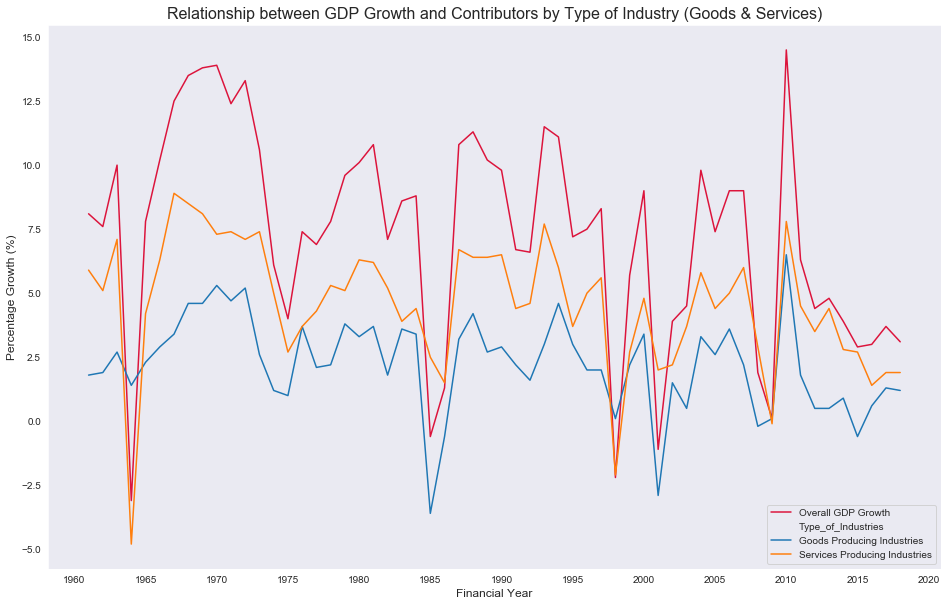

```python
import seaborn as sns
import matplotlib.pyplot as plt
import matplotlib.ticker as ticker

sns.set_style("dark")

gdp_growth = pd.read_csv("./Datasets/contribution-to-growth-in-gross-domestic-product-in-chained-2015-dollars-annual.csv",index_col="year")

#drop column which specify every row as gdp growth rate
gdp_growth.drop(["level_1"],axis=1,inplace=True)

#declaring figure and axes to plot
fig,ax = plt.subplots(figsize=(16,10))

gdp_growth_by_industry = pd.read_csv("./Datasets/contribution-to-growth-in-gdp-in-chained-2015-dollars-by-industry-annual.csv")

#renaming the column name
gdp_growth_by_industry.rename(columns=
    {"year":"Financial Year",
     'level_2':"Type_of_Industries",
     "value":"Percentage Growth (%)"}
    ,inplace=True)

gdp_growth_by_industry = gdp_growth_by_industry[gdp_growth_by_industry.Type_of_Industries.isin(["Goods Producing Industries","Services Producing Industries"])].reset_index()
gdp_growth_by_industry.drop(["level_1"],axis=1,inplace=True)

#plotting overall gdp_growth using matplotlib
ax.plot(gdp_growth,label="Overall GDP Growth",color="crimson")

#plotting gdp_growth for goods and services producing industry using seaborn
sns.lineplot(x='Financial Year', y='Percentage Growth (%)', hue='Type_of_Industries', data=gdp_growth_by_industry)

#displaying legend for the individual lines
ax.legend()

#set the frequency of the xticks and yticks on the x-axis and y-axis
ax.xaxis.set_major_locator(ticker.MultipleLocator(5))

#set the title of the graph
ax.set_title("Relationship between GDP Growth and Contributors by Type of Industry (Goods & Services)",fontsize=16)

#setting label and fontsize for x_axis and y_axis
plt.xlabel('Financial Year', fontsize=12),plt.ylabel("Percentage Growth (%)",fontsize=12)

#show the figure
plt.show()
```

### For the chosen datasets, explain the nature of that dataset (i.e. what is in that dataset) or any pecularities about it you wish to highlight and explain the process you went through to analyse that dataset, . Where possible, you should specifically mention how you used the Pandas, Matplotlib, Seaborn functions to achieve a certain outcome e.g. to transform the data or to produce a certain visualization:

### Process of using Pandas, Matplotlib or Seaborn functions to transform the data:

#### Using Pandas to transform GDP growth dataset

For the GDP Growth dataset, I first rename the column names of the dataset using the rename method. Then, I used the shape method to see the number of rows and columns. After that, I call the method .index and .columns to get the index range and column names of the dataset. Then, I used the head and tail method to see the first and last 5 rows of dataset. I also want to retrieve summary information of the dataset so I apply the info method of the dataset to determine the data type of the columns. I was interested in the years whether singapore is experiencing the fastest gdp growth so I sort the percentage growth by descending order and calling the head method. Similarly, I was interested in the years where singapore experienced the slowest gdp growth so I sort the dataset in descending order and calling the tail method.

Besides that, I am also interested to learn about the average gdp growth every ten years from 1960s to 2010s as well the individual gdp growth during that period. Hence, I used an enumerate and zip function to loop every 10 years to calculate and display the average gdp growth for that period as well using the pivot to convert the column gdp to index to display the gdp growth for that period (e.g in 1960s).

#### Using Pandas to transform GDP growth by industry dataset

For the GDP Growth by industry dataset, most of the methods that were applied at the start were similar to the GDP Growth Dataset but I make a few changes to the last few methods. I am interested to understand the statistcial information for the gdp contribution in individual industry so I applied the describe method on the groupby - sorted by the type of industries for all the data. However, I am still curious to learn about statistical information for the period every 10 years for the individual industries so I used a loop to enumerate and display the information using the groupby to sort by type of industries.

#### Using Matplotlib and/or Seaborn functions to transform the data:

After that, I filter the gdp growth by industry only for the goods producing industry and services producing industry as they are a strong indicator for fluctauations in the gdp growth rate. This is because after extracting the statistical information for all four industries ("Goods Producing Industries" ,"Services Producing Industries","Ownership Of Dwellings","Add: Taxes On Products") using the pandas package, I found out that contribution to gdp for ownership of dwellings and taxes on products always hover at the same growth rate between 2% and -2%. Hence, It is difficult to establish the relationship between the GDP Growth rate for that year as well as the contributors to gdp growth rate for these two respective industries.

Therefore, I specified to only filter for the goods and services producing industries as they offer a much better picture of the relationship between them. After doing that, I reset the index and drop the level 1 for the gdp growth dataset as it is no longer needed. After that, I plot the gdp growth rate and the contributors to the gdp growth rate for goods and services industry using matplotlib for the gd growth rate and seaborn lineplot for the contributors. Then I called the method ax.legend and set the xtick frequency to period of 5.

### For each dataset, highlight the insights you have gained from analysing the data and any conclusions or recommendations you want to make as a result of the analysis:

To answer the first question, I am able to tell that there is a very strong correlation between the contributors to the GDP Growth Rate as well as the anually GDP Growth Rate. This is evident as from the graph, I am able to tell that when the overall gdp growth rate decreases, the GDP Contribution for the goods producing and services producing industries decreases as well.

Moving on on the second question, I am able to tell that from the graph, there are a period of years that experience very strong fluctuations such as the year 1964,1986,1998 and 2001. In order to understand why the GDP Figures fluctuate a lot from these period of time, there is need to know how global events influence singapore's economic performance.

Singapore is one of the Southeast Asia countries and it relies heavily on strong trade and financial linkages with the region. In 1998, Singapore was experiencing an Asian Financial Crisis which was caused by currency devaluations of the thailand's currency. This has resulted in a large portion of asian currencies fell and a reduce in demand for bilaterial trade by countries affected by it.

With that decrease in demand, the goods producing industries in Singapore suffered a sharp decline for trade demands and this has also indirectly affected the services producing industries in Singapore.As such, Singapore is very vulnerable to economic events that happen around us and that contributes to why Singapore's GDP figures constantly fluctuates.

One of the reasons why Singapore is experiencing this is because during the early years of Singapore's development, Singapore is still at the early stages of economic progress and the economic development is still not intertwined deeply with foreigh countries.